# EP07-respuesta-equipo-4

2025-04-30

```r
knitr::opts_chunk$set(echo = TRUE)
library(ggplot2)
library(ggpattern)
library(ggpubr)
library(dplyr)
library(tidyr)
library(scales)
library(gridExtra)
```

# Enunciado

En el trabajo de título de una estudiante del DIINF se reportan tiempos de ejecución (en milisegundos) y la cercanía con la solución óptima (en por ciento) de la mejor solución encontrada con tres versiones de un algoritmo genético para resolver instancias del problema del vendedor viajero disponibles en repositorios públicos. Ahora debe enfrentar el análisis de estos datos, por que está solicitando ayuda de las y los estudiantes de Estadística Inferencial.

```r
datos <- read.csv("EP07 Datos.csv")
head(datos)
```

```
##   instancia n.nodos n.aristas tiempo.A tiempo.B tiempo.C mejor.A mejor.B
## 1         1      50       631   107534   452595   257485   98.72   98.25
## 2         2      50       521    74808   364061   207297   98.99   99.17
## 3         3      50       588    94072   417798   237793   99.10   99.23
## 4         4      50       653   114830   470701   267598   98.69   99.23
## 5         5      50       597    96720   425233   241770   99.80   99.22
## 6         6      50       564    86688   398448   226833   99.19   99.15
##   mejor.C
## 1   99.34
## 2   99.48
## 3   99.10
## 4   97.82
## 5   98.14
## 6   98.04
```

## Pregunta 1

Observando los datos, la memorista sospecha que hay diferencias significativas en el tiempo de ejecución entre las versiones B y C del algoritmo cuando las instancias tienen 65 o más nodos. ¿Los datos respaldan la intuición de la memorista? Para responder, filtren los datos para tener las instancias con 65 o más nodos y seleccionen las columnas de los tiempos de ejecución de las versiones B y C en formato ancho. Usando como semilla el valor 73, obtenga muestras aleatorias independientes de 24 tiempos registrados por la versión B y 20 tiempos registrados por la versión C del algoritmo. Realicen un análisis estadístico pertinente (enunciar hipótesis, revisar condiciones, seleccionar pruebas ómnibus y post-hoc según corresponda) para responder la pregunta planteada, utilizando pruebas no paramétricas de ser necesario.

## Respuesta Pregunta 1

```r
# NIVEL DE SIGNIFICANCIA:
alfa <- 0.05

tamaño_B <- 24
tamaño_C <- 20

set.seed(73)
datos_seleccion <- datos %>%
  filter(n.nodos >= 65) %>%
  select(instancia, tiempo.B, tiempo.C) %>%
  sample_n(tamaño_B + tamaño_C)

datos_formato_largo <- data.frame(
  instancia = datos_seleccion[["instancia"]],
  algoritmo = c(rep("B", tamaño_B), rep("C", tamaño_C)),
  tiempo = c(datos_seleccion[["tiempo.B"]][1:tamaño_B],
             datos_seleccion[["tiempo.C"]][(tamaño_B+1):(tamaño_B+tamaño_C)])
)

datos_formato_largo$algoritmo <- factor(datos_formato_largo$algoritmo)
datos_formato_largo$instancia <- factor(datos_formato_largo$instancia)

head(datos_formato_largo)
```

```
##   instancia algoritmo  tiempo
## 1       101         B 2279894
## 2       111         B 2269588
## 3       128         B 2638637
## 4       153         B 2970598
## 5        57         B 1048648
## 6        87         B 1627230
```

Hipótesis a contrastar:

- **Hipótesis nula (H0):** No hay diferencia significativa entre los tiempos de las versiones B y C.
- **Hipótesis alternativa (H1):** Hay diferencia significativa entre los tiempos de las versiones B y C.

Para elegir una prueba, primero revisamos la normalidad de los datos:

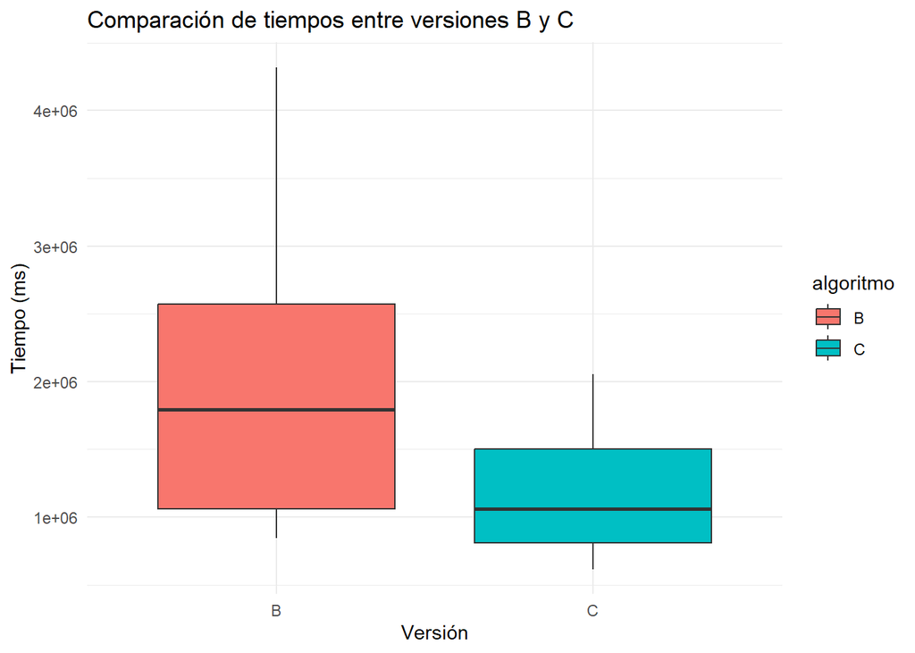

```r
ggplot(datos_formato_largo, aes(x = algoritmo, y = tiempo, fill = algoritmo)) +
  geom_boxplot() +
  theme_minimal() +
  labs(title = "Comparación de tiempos entre versiones B y C",
       x = "Versión", y = "Tiempo (ms)")
```

Con el grafico de caja, se determina que existe asimetría en los datos, por lo que se puede concluir que no siguen una distribución normal.

Verificaremos si se cumplen las condiciones para usar la prueba de suma de rangos de Wilcoxon:

1. Las observaciones de las muestras son independientes, ya que se hizo una selección aleatoria y el tiempo de ejecución de una versión del algoritmo no afecta a la otra.
2. Ya que la variable se mide en milisegundos, se cumple la condición de que la escala es a lo menos ordinal.

Ya que se cumplen las condiciones, se procede a realizar la prueba de Wilcoxon para muestras independientes:

```r
tiempos_B <- datos_seleccion[["tiempo.B"]][1:tamaño_B]
tiempos_C <- datos_seleccion[["tiempo.C"]][(tamaño_B+1):(tamaño_B+tamaño_C)]

#PRUEBA DE WILCOXON
wilcox.test(tiempos_B, tiempos_C, paired = FALSE, alternative = "two.sided", conf.int = TRUE)
```

```
##
##  Wilcoxon rank sum exact test
##
## data:  tiempos_B and tiempos_C
## W = 365, p-value = 0.002705
## alternative hypothesis: true location shift is not equal to 0
## 95 percent confidence interval:
##   152810 1234171
## sample estimates:
## difference in location
##               671765.5
```

Considerando un nivel de significancia de 0.05 y un valor p de 0.002705, se rechaza la hipótesis nula en favor de la alternativa, lo que indica que hay diferencias significativas en el tiempo de ejecución entre las versiones B y C del algoritmo cuando las instancias tienen 65 o más nodos.

## Respuesta Pregunta 2

Dado a que se nos pide verificar si las mejores soluciones encontradas por las versiones A y B tienen rendimientos distintos, podemos identificar cuáles serán nuestras hipótesis a docimar, las cuales son:

- **Hipótesis nula (H0):** No hay diferencia significativa entre los rendimientos de las versiones A y B.
- **Hipótesis alternativa (H1):** Hay diferencia significativa entre los rendimientos de las versiones A y B.

Una vez tenemos las hipótesis a docimar procederemos a analizar los datos para determinar cuál es la mejor prueba para evaluar estas mismas. En este caso dado a que se quieren comparar dos rendimientos para una misma instancia, podemos notar que se trata de una prueba pareada, por lo que es posible usar una prueba t-student para muestras pareadas, pero antes de esto es necesario verificar la normalidad de los datos para determinar si se cumplen los requisitos para esta prueba.

Para esta tarea primero filtramos los datos para tener las instancias con 65 o más nodos y seleccionamos las columnas con el mejor rendimiento de las versiones A y B en formato ancho. Usando como semilla el valor 13, obteniendo una muestra aleatoria de 22.

```r
set.seed(13)
datos_filtrados <- datos %>%
  filter(n.nodos >= 65) %>%
  select(instancia, mejor.A, mejor.B) %>%
  sample_n(22)
head(datos_filtrados)
```

```
##   instancia mejor.A mejor.B
## 1        43   98.58   98.01
## 2       141   99.56   97.84
## 3       114   97.48   94.46
## 4       117   97.01   91.48
## 5        46   99.42   96.36
## 6        88   97.05   94.60
```

```r
mejoresA <- datos_filtrados$mejor.A
mejoresB <- datos_filtrados$mejor.B
```

Una vez tenemos los datos filtrados procederemos a realizar la prueba de normalidad de shapiro-wilk y graficar un diagrama de cajas para determinar si los datos siguen una distribución normal.

```r
shapiroA <- shapiro.test(mejoresA)
shapiroB <- shapiro.test(mejoresB)
shapiroA
```

```
##
##  Shapiro-Wilk normality test
##
## data:  mejoresA
## W = 0.87621, p-value = 0.01024
```

```r
shapiroB
```

```
##
##  Shapiro-Wilk normality test
##
## data:  mejoresB
## W = 0.90382, p-value = 0.03547
```

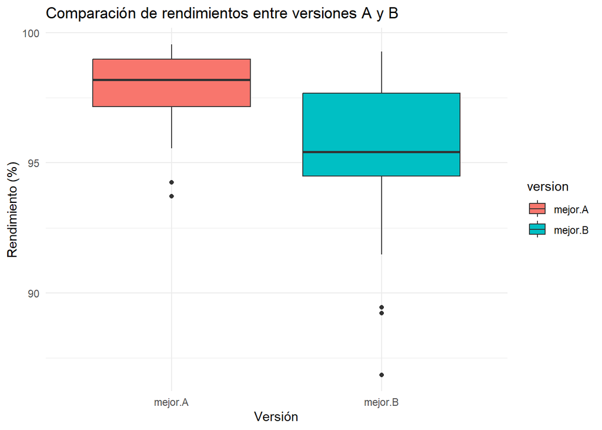

```r
datos_largo <- datos_filtrados %>%
  pivot_longer(cols = c(mejor.A, mejor.B), names_to = "version", values_to = "rendimiento")

ggplot(datos_largo, aes(x = version, y = rendimiento, fill = version)) +
  geom_boxplot() +
  theme_minimal() +
  labs(title = "Comparación de rendimientos entre versiones A y B",
       x = "Versión", y = "Rendimiento (%)")
```

Puesto a que los datos presentan una cierta asimetría y se pueden observar valores atípicos, además de que las pruebas de shapito-wilk nos indican valores p-value de 0.01024 para A y 0.03547 para B, se concluye que los datos no siguen una distribución normal, por lo que no se puede usar la prueba t-student para muestras pareadas. Es por esto que se opta por usar la prueba de rangos con signo de Wilcoxon, la cual no requiere que los datos sigan una distribución normal, pero antes de realizarla es necesario verificar si se cumplen los requisitos para esta prueba, es decir, que los datos sean independientes y que la escala con la que se mide sea a lo menos ordinal. En este caso, los datos son independientes ya que cada instancia es única y no se repite en la muestra, en cuanto a la escala de medición, los datos son medidos en porcentaje, lo que cumple con el requisito de ser al menos ordinal.

Al cumplir con los requisitos para la prueba de rangos con signo de Wilcoxon, procederemos a realizar la prueba para determinar si hay una diferencia significativa entre los rendimientos de las versiones A y B.

```r
wilcox_test <- wilcox.test(mejoresA, mejoresB, paired = TRUE, alternative = "two.sided")
wilcox_test
```

```
##
##  Wilcoxon signed rank exact test
##
## data:  mejoresA and mejoresB
## V = 230, p-value = 0.0003047
## alternative hypothesis: true location shift is not equal to 0
```

Puesto que el p-value de la prueba realizada da como resultado 0.0003047, lo que es menor al nivel de significancia de 0.05, se rechaza la hipótesis nula (H0) en favor de la alternativa (H1), por lo que se concluye que la memorista tenía razón, pues existe una diferencia significativa entre los rendimientos de las versiones A y B en instancias con 65 nodos o más.

## Pregunta 3

La memorista sospecha que hay diferencias significativas en el tiempo de ejecución entre las versiones del algoritmo cuando las instancias de prueba tienen 50 o más nodos. ¿Los datos respaldan la intuición de la memorista? Para responder, filtren los datos para tener las instancias con 50 o más nodos y seleccionen las columnas con los tiempos de ejecución registrados (en formato ancho). Usando como semilla el valor 31, obtengan muestras aleatorias independientes de 15, 14 y 13 tiempos registrados por las versiones A, B y C, respectivamente. Realicen un análisis estadístico pertinente (enunciar hipótesis, revisar condiciones, seleccionar pruebas ómnibus y post-hoc según corresponda) para responder la pregunta planteada, utilizando pruebas no paramétricas de ser necesario.

## Respuesta Pregunta 3

Para responder esta pregunta se debe filtrar el conjunto de datos para obtener las instancias con 50 o más nodos y seleccionar las columnas con los tiempos de ejecución registrados (en formato ancho). Y luego pasar los datos a formato largo para poder trabajar con ellos.

```r
datos_filtrados <- datos %>%
  filter(n.nodos >= 50) %>%
  select(instancia, tiempo.A, tiempo.B, tiempo.C)

tamaño_A <- 15
tamaño_B <- 14
tamaño_C <- 13

tamaño_total <- tamaño_A + tamaño_B + tamaño_C

set.seed(31)


i <- sample(1:nrow(datos_filtrados), tamaño_total)
seleccion <- datos_filtrados[i, ]


muestra_A <- seleccion[["tiempo.A"]][1:tamaño_A]
muestra_B <- seleccion[["tiempo.B"]][(tamaño_A + 1):(tamaño_A + tamaño_B)]
muestra_C <- seleccion[["tiempo.C"]][(tamaño_A + tamaño_B + 1):(tamaño_total)]

datos_largo <- data.frame(instancia = seleccion[["instancia"]],
                          tiempo = c(muestra_A, muestra_B, muestra_C),
                          algoritmo = rep(c("A", "B", "C"), times = c(tamaño_A, tamaño_B, tamaño_C)))

datos_largo$algoritmo <- factor(datos_largo$algoritmo)
datos_largo$instancia <- factor(datos_largo$instancia)

head(datos_largo)
```

```
##   instancia  tiempo algoritmo
## 1        49  398278         A
## 2        75  694845         A
## 3       168 3307370         A
## 4        43  318794         A
## 5        55  453516         A
## 6        27  205476         A
```

Hipótesis a contrastar:

- **Hipótesis nula (H0):** No hay diferencias significativas en el tiempo de ejecución entre las versiones A, B y C del algoritmo cuando las instancias de prueba tienen 50 o más nodos.
- **Hipótesis alternativa (H1):** Hay diferencias significativas en al menos uno de los tiempos de ejecución entre las versiones A, B y C del algoritmo cuando las instancias de prueba tienen 50 o más nodos.

A continuación, se verificará la normalidad de los datos para seleccionar una prueba adecuada:

```r
datos_largo$tiempo_s <- datos_largo$tiempo / 1000

head(datos_largo)
```

```
##   instancia  tiempo algoritmo tiempo_s
## 1        49  398278         A  398.278
## 2        75  694845         A  694.845
## 3       168 3307370         A 3307.370
## 4        43  318794         A  318.794
## 5        55  453516         A  453.516
## 6        27  205476         A  205.476
```

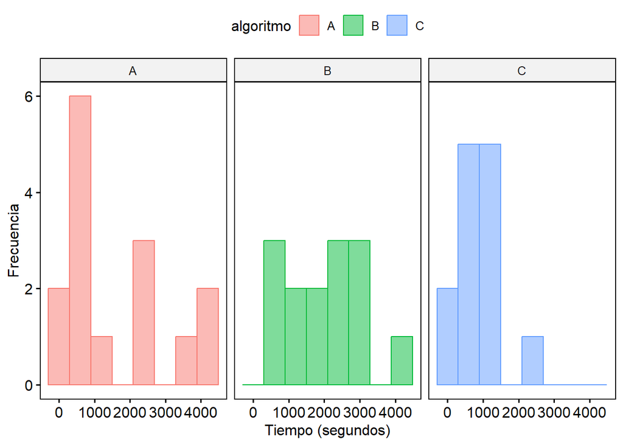

```r
gghistogram(
  datos_largo,
  x = "tiempo_s",
  bins = 8,
  fill = "algoritmo",
  color = "algoritmo",
  facet.by = "algoritmo"
) +  labs(x = "Tiempo (segundos)", y = "Frecuencia")
```

Dado que los histogramas muestran una clara asimetría, principalmente en el algoritmo A y C, es por ello que se considera la prueba de Kruskal-Wallis como prueba no paramétrica para comparar las tres muestras independientes.

Se comienza verificando las condiciones para el uso de la prueba Kruskal-Wallis:

1. Ya que la variable se mide en milisegundos, se cumple la condición de que la escala es a lo menos ordinal.
2. Las observaciones de las muestras son independientes, ya que se hizo una selección aleatoria y el tiempo de ejecución de una versión del algoritmo no afecta a la otra.
3. La variable independiente (versión del algoritmo) es categórica y tiene tres niveles (A, B y C).

Ya que verificamos las condiciones, aplicamos la prueba de Kruskal-Wallis para comparar las tres muestras independientes.

```r
prueba <- kruskal.test(tiempo ~ algoritmo, data = datos_largo)

prueba
```

```
##
##  Kruskal-Wallis rank sum test
##
## data:  tiempo by algoritmo
## Kruskal-Wallis chi-squared = 6.508, df = 2, p-value = 0.03862
```

Considerando un nivel de significancia de 0.05 y un valor p de 0.038, se rechaza la hipótesis nula, lo que indica que hay diferencias significativas en el tiempo de ejecución entre al menos dos de las versiones del algoritmo.

Considerando esta conclusión es necesario aplicar un procedimiento post-hoc para identificar que algoritmos presentan diferencias significativas entre sí, en este caso se usara el método de Benjamini-Hochberg (BH) para ajustar los valores p.

```r
post_hoc <- pairwise.wilcox.test(datos_largo$tiempo, datos_largo$algoritmo, p.adjust.method = "BH", paired = FALSE)

post_hoc
```

```
##
##  Pairwise comparisons using Wilcoxon rank sum exact test
##
## data:  datos_largo$tiempo and datos_largo$algoritmo
##
##   A     B
## B 0.258 -
## C 0.525 0.014
##
## P value adjustment method: BH
```

Se evidencia que no hay diferencia significativa (p > 0.05) entre el algoritmo A y C, y los algoritmos A y B. Sin embargo, hay diferencia significativa (p < 0.05) entre el algoritmo B y C.

## Pregunta 4

La memorista también sospecha que, al comparar las mismas instancias con iguales características, las mejores soluciones encontradas por las diferentes versiones del algoritmo tienen rendimientos distintos. ¿Estará en lo cierto? Para responder, filtren los datos para tener las instancias con 50 o más nodos y seleccionen las columnas con los mejores rendimientos registrados. Usando como semilla el valor 73, obtengan una muestra aleatoria de 22 instancias. Lleven los datos a formato largo y utilicen una prueba no paramétrica apropiada para analizar los datos obtenidos. Realicen un análisis estadístico pertinente (enunciar hipótesis, revisar condiciones, seleccionar pruebas ómnibus y post-hoc según corresponda) para responder la pregunta planteada, utilizando pruebas no paramétricas de ser necesario.

## Respuesta Pregunta 4

Hipótesis a contrastar:

- **Hipótesis nula (H0):** Las mejores soluciones encontradas por las diferentes versiones del algoritmo tienen rendimientos iguales.
- **Hipótesis alternativa (H1):** Las mejores soluciones encontradas por las diferentes versiones del algoritmo tienen al menos un rendimiento distinto.

```r
# FILTRADO DE VALORES:
ej_4 <- datos |> filter(n.nodos >= 50) |>
  select(mejor.A, mejor.B, mejor.C) |>
  sample_n(22, replace = FALSE, set.seed(73))


# PASADO A FORMATO LARGO:
ej_4_largo <- ej_4 |>
  pivot_longer(cols = everything(), names_to = "version", values_to = "rendimiento") |>
  mutate(Instancia = rep(1:22, each = 3))

head(ej_4_largo)
```

```
## # A tibble: 6 × 3
##   version rendimiento Instancia
##   <chr>         <dbl>     <int>
## 1 mejor.A        97.2         1
## 2 mejor.B        97.2         1
## 3 mejor.C        97.6         1
## 4 mejor.A        99.3         2
## 5 mejor.B        95.0         2
## 6 mejor.C        98.2         2
```

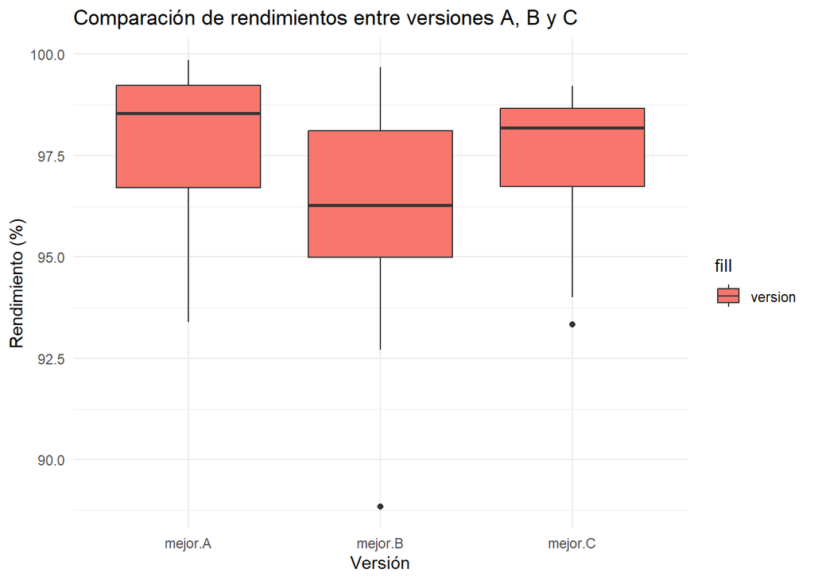

```r
ggplot(ej_4_largo, aes(x = version, y = rendimiento, fill = "version")) +
  geom_boxplot() +
  theme_minimal() +
  labs(title = "Comparación de rendimientos entre versiones A, B y C",
       x = "Versión", y = "Rendimiento (%)")
```

Como se puede ver en el diagrama de cajas, los datos presentan asimetría, lo que indica que no siguen una distribución normal, por lo que sería adecuado usar la prueba de Friedman. Además, dado que existen valores atípicos, se define el nivel de significancia como 0.01, para evaluar con mayor precisión.

Se procede a verificar las condiciones de la prueba Friedman:

1. La variable dependiente (rendimiento) es continua y se mide en porcentaje, lo que cumple con la condición de ser al menos ordinal.
2. Las observaciones de las muestras son independientes, ya que se hizo una selección aleatoria y el rendimiento de una versión del algoritmo no afecta a la otra.
3. La variable independiente (versión del algoritmo) es categórica y tiene tres niveles (A, B y C).

Con el cumplimiento de las condiciones se procede a realizar la prueba de Friedman:

```r
# PRUEBA DE FRIEDMAN
prueba <- friedman.test(rendimiento ~ version | Instancia, data = ej_4_largo)
prueba
```

```
##
##  Friedman rank sum test
##
## data:  rendimiento and version and Instancia
## Friedman chi-squared = 13.364, df = 2, p-value = 0.001253
```

Como es posible de observar, el valor p obtenido 0.001253 es menor al nivel de significancia de 0.01, lo que indica que existe al menos un rendimiento distinto dentro de las mejores soluciones encontradas por las diferentes versiones del algoritmo. Es por lo previamente mencionado que es necesario realizar una prueba Post-hoc con el objetivo de conocer cual o cuales son los rendimientos que presentan esta diferencia.

```r
# NIVEL DE SIGNIFICANCIA:
alfa <- 0.01

# PRUEBA POST HOC
posthoc <- pairwise.wilcox.test(ej_4_largo$rendimiento, ej_4_largo$version, p.adjust.method = "holm", paired = TRUE, exact = FALSE)
posthoc
```

```
##
##  Pairwise comparisons using Wilcoxon signed rank test with continuity correction
##
## data:  ej_4_largo$rendimiento and ej_4_largo$version
##
##         mejor.A mejor.B
## mejor.B 0.0021  -
## mejor.C 0.2558  0.0502
##
## P value adjustment method: holm
```

Gracias a este resultado es posible observar que, con un 99% de confianza:

- mejor.A presenta una diferencia con respecto a mejor.B, pues presenta un valor menor a 0.01.
- mejor.A no presenta diferencia con respecto a mejor.C pues posee un valor mayor a 0.01.
- mejor.B no presenta diferencia con respecto a mejor.B pues posee un valor mayor a 0.01.